# BIA 6304 Predictive Models Fall 2017

## Assignment 3

## Notebook 1

### Stuent: Leonardo Ji

### 12/8/2017

Part 1: MCMC

In the GNP MCMC example done in class, modify some of the likelihood assumptions of each of the parameters to estimate (you can also try one at a time). How does this change the posterior distribution sampling and PDF (as well as the estimate evaluations)? Also, how does it changes as you adjust the number of iterations. One paragraph to explain the changes

### Import Standard packages

```python
%matplotlib inline
import pymc3 as pm
import numpy as np
import scipy.stats as stats
import matplotlib.pyplot as plt
import seaborn as sns
palette = 'muted'
sns.set_palette(palette); sns.set_color_codes(palette)
```

# PyMC3 primer

### Generate 10 random variables 0 or 1

```python
np.random.seed(123)
# change number of experiements
n_experiments = 10
# actual probability
theta_real = 0.30  # unknown value in a real experiment
data = stats.bernoulli.rvs(p=theta_real, size=n_experiments)
data
```

```
array([0, 0, 0, 0, 1, 0, 1, 0, 0, 0])
```

```python
with pm.Model() as our_first_model:
    # a priori
    theta = pm.Beta('theta', alpha=2, beta=2)
    # likelihood
    y = pm.Bernoulli('y', p=theta, observed=data)
    #y = pm.Binomial('theta',n=n_experimentos, p=theta, observed=sum(datos))
    start = pm.find_MAP() # Use MAP estimate (optimization) as the initial state for MCMC
    step = pm.Metropolis() # Have a choice of samplers
    trace = pm.sample(1000, step=step, start=start)
```

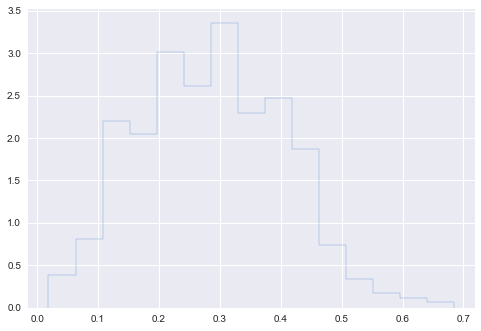

```python
plt.hist(trace['theta'], 15, histtype='step', normed=True, label='post');
```

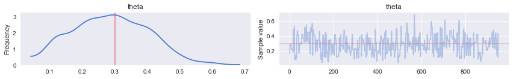

```python
burnin = 50  # no burnin
chain = trace[burnin:]
pm.traceplot(chain, lines={'theta':theta_real});
plt.savefig('B04958_02_04.png', dpi=300, figsize=(5.5, 5.5))
```

```python
with our_first_model:
    step = pm.Metropolis()
    multi_trace = pm.sample(1000, step=step, njobs=4)
```

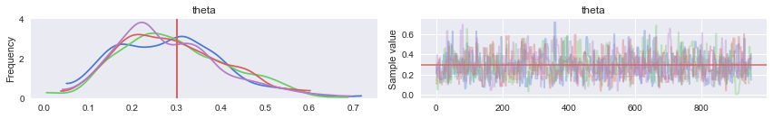

```python
burnin = 50  # no burnin
multi_chain = multi_trace[burnin:]
pm.traceplot(multi_chain, lines={'theta':theta_real});
plt.savefig('B04958_02_06.png', dpi=300, figsize=(5.5, 5.5))
```

```python
pm.gelman_rubin(multi_chain)
```

```
{'theta': 1.0004065173159322}
```

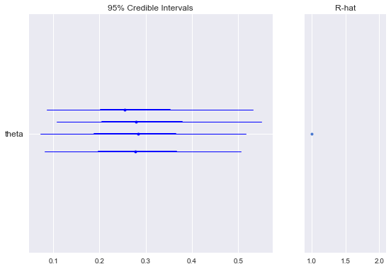

```python
pm.forestplot(multi_chain, varnames=['theta']);
plt.savefig('B04958_02_07.png', dpi=300, figsize=(5.5, 5.5))
```

```python
pm.summary(multi_chain)
```

```
theta:

  Mean             SD               MC Error         95% HPD interval
  -------------------------------------------------------------------

  0.288            0.120            0.004            [0.085, 0.532]

  Posterior quantiles:
  2.5            25             50             75             97.5
  |--------------|==============|==============|--------------|

  0.094          0.197          0.276          0.364          0.552
```

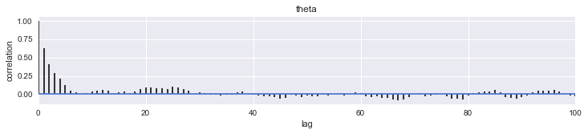

```python
pm.autocorrplot(chain)
plt.savefig('B04958_02_08.png', dpi=300, figsize=(5.5, 5.5))
```

```python
pm.effective_n(multi_chain)['theta']
```

```
803.0
```

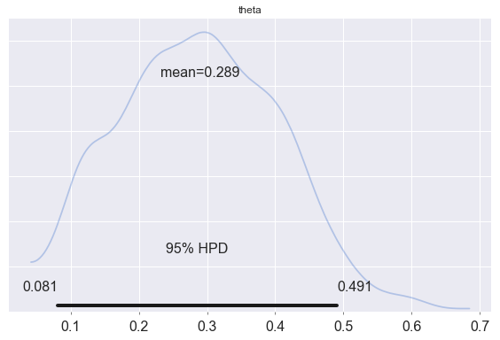

```python
pm.plot_posterior(chain, kde_plot=True)
plt.savefig('B04958_02_09.png', dpi=300, figsize=(5.5, 5.5))
```

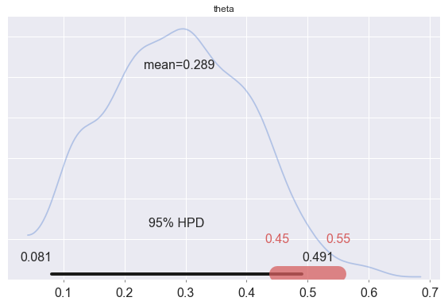

```python
pm.plot_posterior(chain, kde_plot=True, rope=[0.45, .55])
plt.savefig('B04958_02_10.png', dpi=300, figsize=(5.5, 5.5))
```

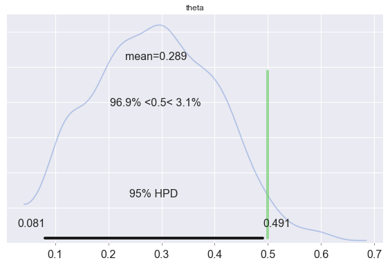

```python
pm.plot_posterior(chain, kde_plot=True, ref_val=0.5)
plt.savefig('B04958_02_11.png', dpi=300, figsize=(5.5, 5.5))
```

# Summary

MCMC stands for Markov Chain Monte Carlo. The goal of MCMC is to estimate an unknown distribution (posterior distribution) using Bayes' Theorem updating prior probability distribution using new data (likelihood distribution).

- We set unknown distribution theta to 0.30, this is the actual probability MCMC tries to estimate.
- We use Bernoulli distribution to produce 10-coin toss (binary 0 or 1).
- Prior distribution is a beta distribution of alpha=2, beta=2.
- The likelihood function is a Bernoulli distribution.
- We use Metropolis Hastings algorithm to run 1000 times MCMC random walk to estimate the target distribution theta. Metropolis Hastings algorithm is an iterative algorithm that rejects (stay to the same state) or accepts (move to a new state) proposals based on the probability of new state is greater than a random number.
- The algorithm estimates actual theta mean is 0.289, and SD s 0.120.